# MixN_ChronicFetal

### Data loading

```r
suppressPackageStartupMessages({
  library(SummarizedExperiment)
  library(SEtools)
  library(edgeR)
  library(DT)
  library(pheatmap)
  library(plotly)
  library(dplyr)
  library(sva)
  library(reshape2)
  library(overlapper)
  library(ggrepel)
})
source("Functions/EDC_Functions.R")
source("Functions/CriFormatted.R")
load("Data/AllSEcorrected.RData",verbose=T)
```

```
## Loading objects:
##   SEs
##   DEAs
```

### DEGs heatmaps

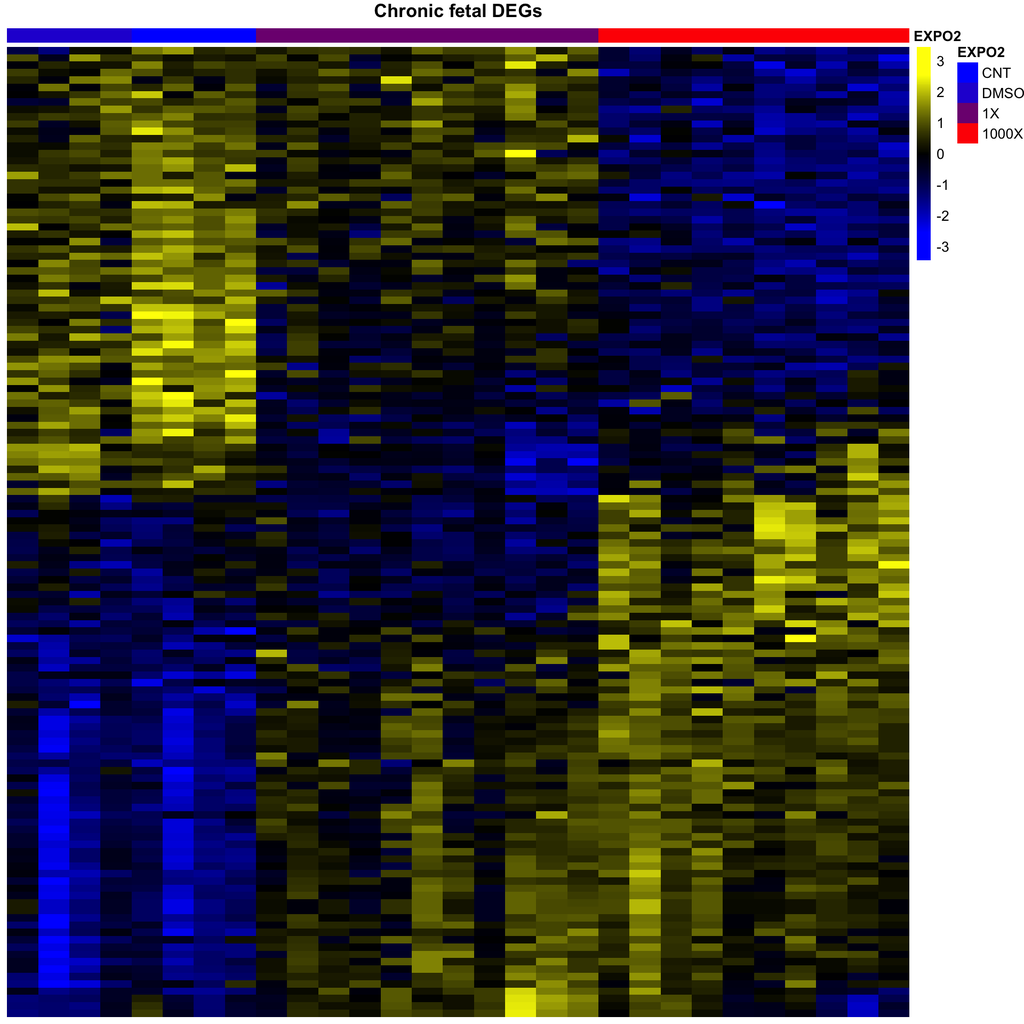

```r
fetal.chronic <- row.names(DEAs$chronic.fetal)[which((abs(DEAs$chronic.fetal$logFC.EXPO1X)>0.5 | abs(DEAs$chronic.fetal$logFC.EXPO1000X)>0.5) & DEAs$chronic.fetal$FDR<=0.05 & DEAs$chronic.fetal$logCPM>0)]


MixN_fetal_chronic <- SEs$chronic.fetal[,which(SEs$chronic.fetal$EXPO=="CNT"|SEs$chronic.fetal$EXPO=="1X" | SEs$chronic.fetal$EXPO=="1000X")]
sehm(MixN_fetal_chronic, assayName = "corrected", fetal.chronic,  do.scale = T, show_rownames = F, anno_columns = c("EXPO2"), main="Chronic fetal DEGs")
```

### 1X vs 1000X

```r
FDRTh <- 0.05
LogFCTh <- 0.5

MixN1X <- DEAs$chronic.fetal
MixN1X$genes <- row.names(MixN1X)
MixN1X$logFC <- (MixN1X$logFC.EXPO1X)

MixN1000X <- DEAs$chronic.fetal
MixN1000X$genes <- row.names(MixN1000X)
MixN1000X$logFC <- (MixN1X$logFC.EXPO1000X)
```

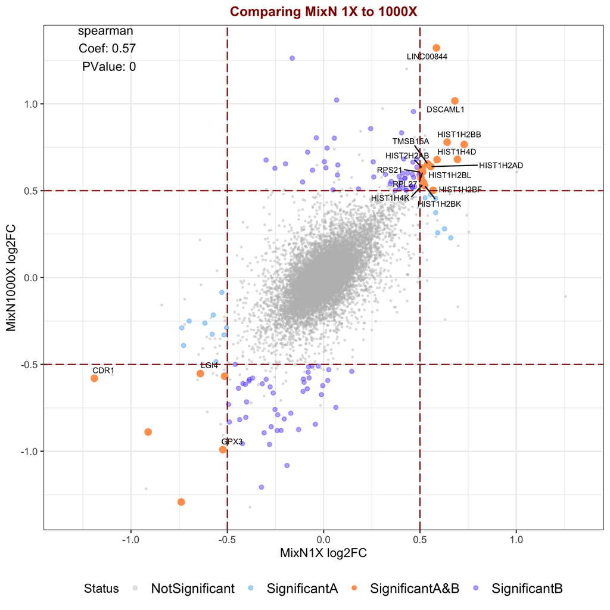

```r
Comp <- compareResultsFCNew(MixN1X, MixN1000X, FDRth=0.05, FCth=2^0.5, FDRceil=1e-10, logCPMth=0, FCceil=2.5,
                              title='Comparing MixN 1X to 1000X', geneLabel=TRUE, topLab=-16)
## Warning in cor.test.default(AllRes$logFC_A, AllRes$logFC_B, method = corMethod):
## Cannot compute exact p-value with ties

Comp$Scatter
```

```r
ggsave(Comp$Scatter, filename='Data/ChronicFetal/Scatter.pdf', width=10, height=10)
ggsave(Comp$Scatter, filename='Data/ChronicFetal/Scatter.png', width=10, height=10)
```

### Neurodevelopmental Disorder Genes

```r
load("Data/ASD.RData", verbose = T)
## Loading objects:
##   ASD
##   SFARI
##   SFARIgenes
##   NeuropsychiatricDiseases
##   PsychencodeNDD

fetal.chronic3 <- row.names(DEAs$chronic.fetal)[which(DEAs$chronic.fetal$FDR<=0.05)]
controlNeg <- row.names(DEAs$chronic.fetal)[-which(DEAs$chronic.fetal$FDR<=0.05)]

#random1 <- sample(row.names(DEAs$chronic.fetal), 10)
#random2 <- sample(row.names(DEAs$chronic.fetal), 100)
#random3 <- sample(row.names(DEAs$chronic.fetal), 1000)

fetal.chronicUp <- row.names(DEAs$chronic.fetal)[which(((DEAs$chronic.fetal$logFC.EXPO1X)>0 & (DEAs$chronic.fetal$logFC.EXPO1000X)>0) & DEAs$chronic.fetal$FDR<=0.05)]
fetal.chronicDown <- row.names(DEAs$chronic.fetal)[which(((DEAs$chronic.fetal$logFC.EXPO1X)<0 & (DEAs$chronic.fetal$logFC.EXPO1000X)<0) & DEAs$chronic.fetal$FDR<=0.05)]


#MixN <- list(fetalDEGs=fetal.chronic3, fetalDEGsUp=fetal.chronicUp, fetalDEGsDown=fetal.chronicDown,NonAffectedGenes=controlNeg)
MixN <- list(fetalDEGs=fetal.chronic3, NonAffectedGenes=controlNeg)

m <- overlapper::multintersect(ll = MixN, ll2 = ASD, universe = row.names(DEAs$chronic.fetal),two.tailed = F)

fetal.chronicLong=fetal.chronic3
save(fetal.chronic,fetal.chronicLong,file = "Data/DEGsFetalChronic.RData")
```

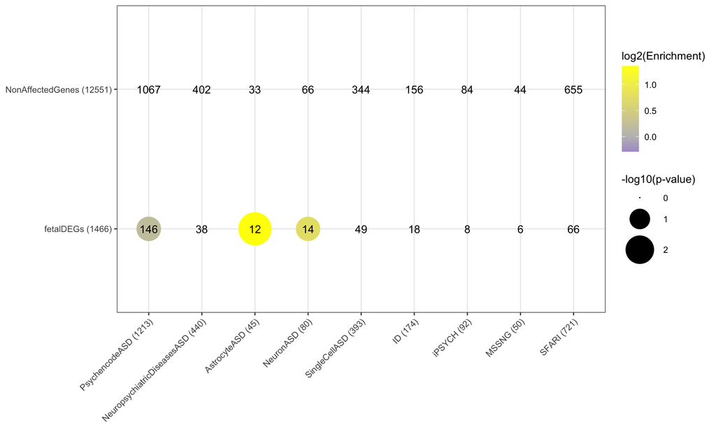

```r
dotplot.multintersect(m, sizeRange = c(0,15), th=0.05)
```

```r
ggsave(dotplot.multintersect(m, th=0.05), filename='Data/ChronicFetal/DotplotFetalNDD.pdf', width=10, height=6)
```

#### P values of the overlaps

```r
m$prob <- round(m$prob, digits=3)
DT::datatable(m$prob)
```

|  | SFARI (721) | MSSNG (50) | iPSYCH (92) | ID (174) | SingleCellASD (393) | NeuronASD (80) | AstrocyteASD (45) | NeuropsychiatricDiseasesASD (440) | PsychencodeASD (1213) |
| --- | --- | --- | --- | --- | --- | --- | --- | --- | --- |
| fetalDEGs (1466) | 0.894 | 0.426 | 0.759 | 0.557 | 0.11 | 0.037 | 0.002 | 0.914 | 0.035 |
| NonAffectedGenes (12551) | 0.132 | 0.735 | 0.365 | 0.543 | 0.917 | 0.982 | 0.999 | 0.115 | 0.971 |

### NDD psychencode

```r
m <- overlapper::multintersect(ll = MixN, ll2 = PsychencodeNDD, universe = row.names(DEAs$chronic.fetal),two.tailed = F)
```

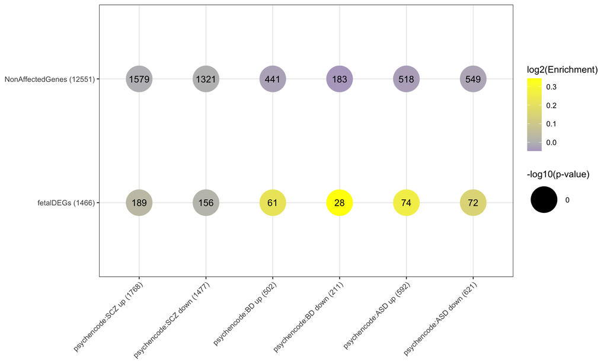

```r
dotplot.multintersect(m, th=0.05)
```

```r
ggsave(dotplot.multintersect(m, th=0.05), filename='Data/ChronicFetal/DotplotFetalNDD.pdf', width=10, height=6)
```

### Gene expression dysregulation of the most important NDD genes

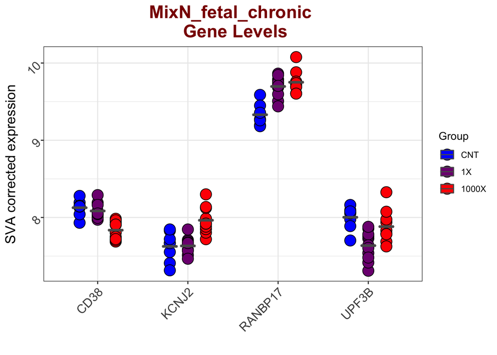

```r
geneStripPairEDCMix(SE = MixN_fetal_chronic,GeneSet = intersect(fetal.chronic, unlist(SFARIgenes)), printExp = FALSE, SampleColors = "Default")
## Warning: `fun.y` is deprecated. Use `fun` instead.
## Warning: `fun.ymin` is deprecated. Use `fun.min` instead.
## Warning: `fun.ymax` is deprecated. Use `fun.max` instead.
```

```r
PVals <- DEAs$chronic.fetal[intersect(fetal.chronic, unlist(SFARIgenes)),]
PVals <- PVals[complete.cases(PVals), ]
PVals
##         logFC.EXPO1X logFC.EXPO1000X   logCPM         F       PValue
## RANBP17   0.42942927       0.5046568 4.315729 15.524431 1.368507e-05
## CD38     -0.07818771      -0.5136144 2.317253 10.633310 2.344008e-04
## UPF3B    -0.69780169      -0.2505012 2.220196  8.283412 1.095909e-03
## KCNJ2     0.01174969       0.6317999 2.352303  6.680355 3.403851e-03
##                 FDR
## RANBP17 0.001026474
## CD38    0.006803033
## UPF3B   0.018808919
## KCNJ2   0.038314035
```

- Genes with conventional PVal > 0.05:
- Genes with conventional PVal < 0.05:
- Genes with conventional FDR < 0.05: RANBP17, CD38, UPF3B, KCNJ2

### Gene expression dysregulation of the chronic organoids NDD-DEGs in fetal dataset

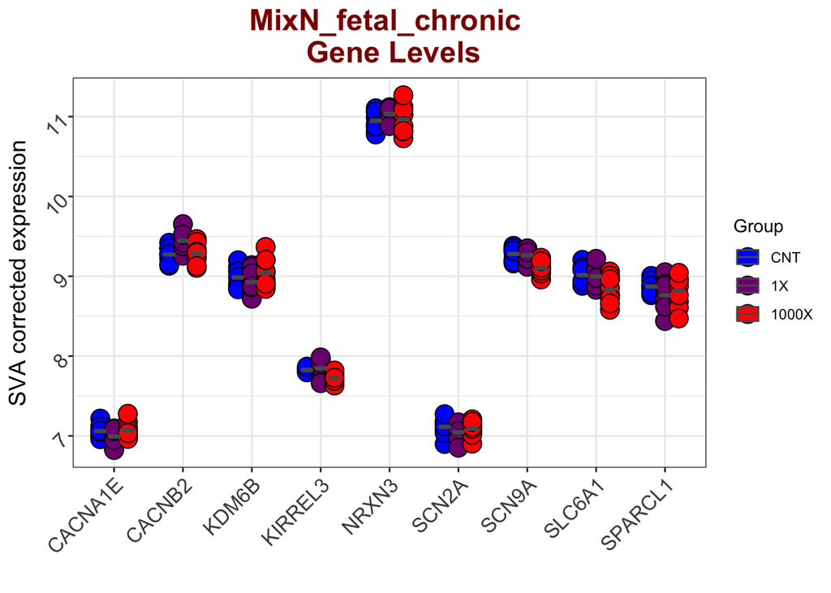

```r
load("Data/DEGsOrganoidsChronic.RData", verbose = T)
## Loading objects:
##   org.chronic
##   org.chronicLong
geneStripPairEDCMix(SE = MixN_fetal_chronic,GeneSet = intersect(org.chronic, union(union(SFARIgenes$score1,SFARIgenes$score2),SFARIgenes$score3)), printExp = FALSE,SampleColors = "Default")
## [1] "Expression values are not available for the following genes: LMX1B CNTN5 FOXP2"
## Warning: `fun.y` is deprecated. Use `fun` instead.
## Warning: `fun.ymin` is deprecated. Use `fun.min` instead.
## Warning: `fun.ymax` is deprecated. Use `fun.max` instead.
```

```r
PVals <- DEAs$chronic.fetal[intersect(org.chronic, union(union(SFARIgenes$score1,SFARIgenes$score2),SFARIgenes$score3)),]
PVals <- PVals[complete.cases(PVals), ]
PVals
##         logFC.EXPO1X logFC.EXPO1000X    logCPM         F       PValue
## SCN9A    -0.02379698     -0.22817909 4.0165210 8.5764810 0.0008975184
## CACNA1E  -0.23420581      0.01300326 0.1448921 1.0890090 0.3473611846
## SCN2A    -0.18687998     -0.07101465 0.2608272 0.3449099 0.7105950709
## SPARCL1  -0.14589917     -0.04707601 3.5113849 0.5094489 0.6050859597
## SLC6A1   -0.01639811     -0.23519283 3.7305288 2.0112246 0.1485613035
## NRXN3     0.08392746      0.01466756 6.1478405 0.7129638 0.4969681974
## CACNB2    0.21680279      0.01476147 4.0805953 4.7232387 0.0150695434
## KDM6B    -0.06400076      0.07252019 3.9159704 0.8225561 0.4473804131
## KIRREL3   0.05531668     -0.19737441 1.9492403 3.8168693 0.0313621709
##                FDR
## SCN9A   0.01661891
## CACNA1E 0.56800767
## SCN2A   0.83594250
## SPARCL1 0.76628869
## SLC6A1  0.35460420
## NRXN3   0.69077479
## CACNB2  0.09452263
## KDM6B   0.65057903
## KIRREL3 0.14465401
```

- Genes with conventional PVal > 0.05: CACNA1E, SCN2A, SPARCL1, SLC6A1, NRXN3, KDM6B
- Genes with conventional PVal < 0.05: CACNB2, KIRREL3
- Genes with conventional FDR < 0.05: SCN9A

### Gene expression dysregulation of the genes found in the acute expo

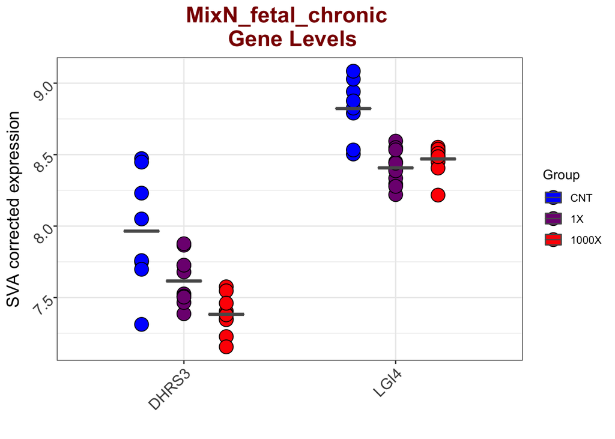

```r
load("Data/DEGsFetalAcute.RData", verbose = T)
## Loading objects:
##   fet.acute
geneStripPairEDCMix(SE = MixN_fetal_chronic,GeneSet = intersect(fet.acute,fetal.chronic), printExp = FALSE,SampleColors = "Default")
## Warning: `fun.y` is deprecated. Use `fun` instead.
## Warning: `fun.ymin` is deprecated. Use `fun.min` instead.
## Warning: `fun.ymax` is deprecated. Use `fun.max` instead.
```

```r
PVals <- DEAs$chronic.fetal[intersect(fet.acute,fetal.chronic),]
PVals <- PVals[complete.cases(PVals), ]
PVals
##       logFC.EXPO1X logFC.EXPO1000X   logCPM         F       PValue         FDR
## DHRS3   -0.7391126      -1.2919270 2.356456  8.279411 1.098918e-03 0.018828021
## LGI4    -0.6400688      -0.5527407 3.324905 14.129351 2.942914e-05 0.001699696
```

- Genes with conventional PVal > 0.05:
- Genes with conventional PVal < 0.05:
- Genes with conventional FDR < 0.05: DHRS3, LGI4

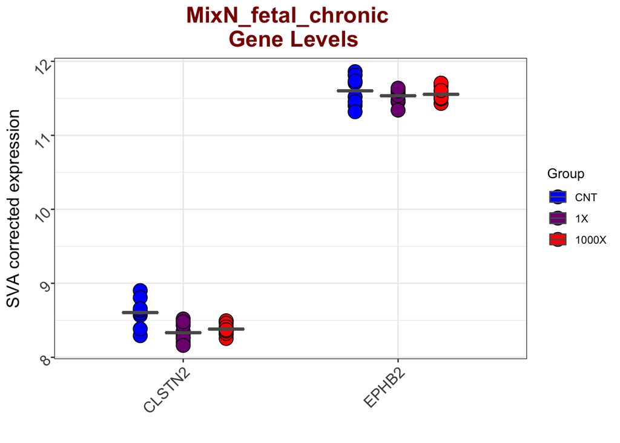

```r
geneStripPairEDCMix(SE = MixN_fetal_chronic,GeneSet = c("CLSTN2", "EPHB2"), printExp = FALSE,SampleColors = "Default")
## Warning: `fun.y` is deprecated. Use `fun` instead.
## Warning: `fun.ymin` is deprecated. Use `fun.min` instead.
## Warning: `fun.ymax` is deprecated. Use `fun.max` instead.
```

```r
PVals <- DEAs$chronic.fetal[c("CLSTN2", "EPHB2"),]
PVals <- PVals[complete.cases(PVals), ]
PVals
##        logFC.EXPO1X logFC.EXPO1000X   logCPM         F      PValue        FDR
## CLSTN2  -0.43177041     -0.36208302 3.102171 5.3919031 0.008939188 0.06884648
## EPHB2   -0.08307527     -0.06479717 6.840971 0.5195956 0.599145992 0.76229730
```

- Genes with conventional PVal > 0.05: EPHB2
- Genes with conventional PVal < 0.05: CLSTN2
- Genes with conventional FDR < 0.05:

### Data praparation

For details on data filtering, normalization, batch correction and differential expression analysis, see here

For details on the preparation of Neurodevelopmental disorder genes, see here

### Index

MixN_Acute

MixN_ChronicFetal

FunctionalFetalChronicMixN

MixN_ChronicOrganoids

FunctionalOrganoidChronicMixN

MixNVsSingleCompounds

MasterRegulatorAnalysis

HormonalPathways

Immunofluorescence

MixN_clustering

FunctionalClustering

DoseResponseInVivo

### Authors

Nicolò Caporale: nicolo.caporale@ieo.it, nicolo.caporale@unimi.it

Cristina Cheroni: cristina.cheroni@ieo.it

Pierre-Luc Germain: pierre-luc.germain@ieo.it

Giuseppe Testa: giuseppe.testa@ieo.it

Lab: http://www.testalab.eu/

‘Date: December 01, 2021’